# Group3

## Group 3: ML Assignment 5

### Objective

To predict which customer is more likely to purchase the newly introduced telecom plan.

### **Data Dictionary**

- **CustomerID:** Unique customer ID
- **PlanTaken:** Whether the customer has purchased the plan or not (0: No, 1: Yes)
- **Age:** Age of customer
- **TypeofContact:** How customer was contacted (Company Invited or Self Inquiry)
- **CityTier:** City tier depends on the development of a city, population, facilities, and living standards. The categories are ordered i.e. Tier 1 > Tier 2 > Tier 3
- **Occupation:** Occupation of customer
- **Gender:** Gender of customer
- **NumberOfPersons:** Total number of persons planning to take the plan with the customer (since these are Friends and Family plans)
- **PreferredServiceStar:** Preferred service rating by customer
- **MaritalStatus:** Marital status of customer
- **NumberOfUpgrades:** Average number of upgrades in a year by customer
- **iPhone:** The customer has an iphone or not (0: No, 1: Yes)
- **PhoneContract:** Whether the customers has a contracted phone or not (0: No, 1: Yes)
- **NumberOfChildren:** Total number of children planning to take the plan with the customer
- **Designation:** Designation of the customer in the current organization
- **MonthlyIncome:** Gross monthly income of the customer
- **PitchSatisfactionScore:** Sales pitch satisfaction score
- **PlanPitched:** Plan pitched by the salesperson
- **NumberOfFollowups:** Total number of follow-ups has been done by the salesperson after the sales pitch
- **DurationOfPitch:** Duration of the pitch by a salesperson to the customer

### Tasks:

- EDA
- Data Cleaning
- Data Visualization
- Feature Engineering & Data Preprocessing
- Model Building & Evaluation
- Model Tuning 3 rounds

### Note:

- Use Logistic Regression w/ Regularization and SVM techniques
- Compare the Logistic Regression technique you use for this problem with SVM techniques and interpret/explain the differences.
- Your models should be tested on at least 1000 randomly selected data points

## Let's start coding!

```python
import pandas as pd
from sklearn.model_selection import train_test_split
from sklearn.preprocessing import OrdinalEncoder, StandardScaler
from matplotlib import pyplot as plt
import seaborn as sns
import numpy as np
from sklearn.svm import SVC
from sklearn.linear_model import LogisticRegression
from sklearn.metrics import accuracy_score, recall_score, precision_score, roc_curve, auc, confusion_matrix
from imblearn.over_sampling import SMOTE
import warnings

warnings.filterwarnings('ignore')
```

### Read the dataset

```python
df_path = '~/code/loyalist-college/sem-1/ml-1/assignment-5/Telecom.xlsx'
df = pd.read_excel(df_path, sheet_name="Telecom")
df.info()
df.describe()
```

```
<class 'pandas.core.frame.DataFrame'>
RangeIndex: 4888 entries, 0 to 4887
Data columns (total 20 columns):
 #   Column                  Non-Null Count  Dtype
---  ------                  --------------  -----
 0   CustomerID              4888 non-null   int64
 1   PlanTaken               4888 non-null   int64
 2   Age                     4662 non-null   float64
 3   TypeofContact           4863 non-null   object
 4   CityTier                4888 non-null   int64
 5   DurationOfPitch         4637 non-null   float64
 6   Occupation              4888 non-null   object
 7   Gender                  4888 non-null   object
 8   NumberOfPersons         4888 non-null   int64
 9   NumberOfFollowups       4843 non-null   float64
 10  PlanPitched             4888 non-null   object
 11  PreferredServiceStar    4862 non-null   float64
 12  MaritalStatus           4888 non-null   object
 13  NumberOfUpgrades        4748 non-null   float64
 14  iPhone                  4888 non-null   int64
 15  PitchSatisfactionScore  4888 non-null   int64
 16  PhoneContract           4888 non-null   int64
 17  NumberOfChildren        4822 non-null   float64
 18  Designation             4888 non-null   object
 19  MonthlyIncome           4655 non-null   float64
dtypes: float64(7), int64(7), object(6)
memory usage: 763.9+ KB
```

|  | CustomerID | PlanTaken | Age | CityTier | DurationOfPitch | NumberOfPersons | NumberOfFollowups | PreferredServiceStar | NumberOfUpgrades | iPhone | PitchSatisfactionScore | PhoneContract | NumberOfChildren | MonthlyIncome |
| --- | --- | --- | --- | --- | --- | --- | --- | --- | --- | --- | --- | --- | --- | --- |
| count | 4888.000000 | 4888.000000 | 4662.000000 | 4888.000000 | 4637.000000 | 4888.000000 | 4843.000000 | 4862.000000 | 4748.000000 | 4888.000000 | 4888.000000 | 4888.000000 | 4822.000000 | 4655.000000 |
| mean | 202443.500000 | 0.188216 | 37.622265 | 1.654255 | 15.490835 | 2.905074 | 3.708445 | 3.581037 | 3.236521 | 0.290917 | 3.078151 | 0.620295 | 1.187267 | 23619.853491 |
| std | 1411.188388 | 0.390925 | 9.316387 | 0.916583 | 8.519643 | 0.724891 | 1.002509 | 0.798009 | 1.849019 | 0.454232 | 1.365792 | 0.485363 | 0.857861 | 5380.698361 |
| min | 200000.000000 | 0.000000 | 18.000000 | 1.000000 | 5.000000 | 1.000000 | 1.000000 | 3.000000 | 1.000000 | 0.000000 | 1.000000 | 0.000000 | 0.000000 | 1000.000000 |
| 25% | 201221.750000 | 0.000000 | 31.000000 | 1.000000 | 9.000000 | 2.000000 | 3.000000 | 3.000000 | 2.000000 | 0.000000 | 2.000000 | 0.000000 | 1.000000 | 20346.000000 |
| 50% | 202443.500000 | 0.000000 | 36.000000 | 1.000000 | 13.000000 | 3.000000 | 4.000000 | 3.000000 | 3.000000 | 0.000000 | 3.000000 | 1.000000 | 1.000000 | 22347.000000 |
| 75% | 203665.250000 | 0.000000 | 44.000000 | 3.000000 | 20.000000 | 3.000000 | 4.000000 | 4.000000 | 4.000000 | 1.000000 | 4.000000 | 1.000000 | 2.000000 | 25571.000000 |
| max | 204887.000000 | 1.000000 | 61.000000 | 3.000000 | 127.000000 | 5.000000 | 6.000000 | 5.000000 | 22.000000 | 1.000000 | 5.000000 | 1.000000 | 3.000000 | 98678.000000 |

# Feature Engineering

## Remove duplicates

```python
df
df.drop_duplicates()
```

|  | CustomerID | PlanTaken | Age | TypeofContact | CityTier | DurationOfPitch | Occupation | Gender | NumberOfPersons | NumberOfFollowups | PlanPitched | PreferredServiceStar | MaritalStatus | NumberOfUpgrades | iPhone | PitchSatisfactionScore | PhoneContract | NumberOfChildren | Designation | MonthlyIncome |
| --- | --- | --- | --- | --- | --- | --- | --- | --- | --- | --- | --- | --- | --- | --- | --- | --- | --- | --- | --- | --- |
| 0 | 200000 | 1 | 41.0 | Self Enquiry | 3 | 6.0 | Salaried | Female | 3 | 3.0 | Deluxe | 3.0 | Single | 1.0 | 1 | 2 | 1 | 0.0 | Manager | 20993.0 |
| 1 | 200001 | 0 | 49.0 | Company Invited | 1 | 14.0 | Salaried | Male | 3 | 4.0 | Deluxe | 4.0 | Divorced | 2.0 | 0 | 3 | 1 | 2.0 | Manager | 20130.0 |
| 2 | 200002 | 1 | 37.0 | Self Enquiry | 1 | 8.0 | Free Lancer | Male | 3 | 4.0 | Basic | 3.0 | Single | 7.0 | 1 | 3 | 0 | 0.0 | Executive | 17090.0 |
| 3 | 200003 | 0 | 33.0 | Company Invited | 1 | 9.0 | Salaried | Female | 2 | 3.0 | Basic | 3.0 | Divorced | 2.0 | 1 | 5 | 1 | 1.0 | Executive | 17909.0 |
| 4 | 200004 | 0 | NaN | Self Enquiry | 1 | 8.0 | Small Business | Male | 2 | 3.0 | Basic | 4.0 | Divorced | 1.0 | 0 | 5 | 1 | 0.0 | Executive | 18468.0 |
| ... | ... | ... | ... | ... | ... | ... | ... | ... | ... | ... | ... | ... | ... | ... | ... | ... | ... | ... | ... | ... |
| 4883 | 204883 | 1 | 49.0 | Self Enquiry | 3 | 9.0 | Small Business | Male | 3 | 5.0 | Deluxe | 4.0 | Unmarried | 2.0 | 1 | 1 | 1 | 1.0 | Manager | 26576.0 |
| 4884 | 204884 | 1 | 28.0 | Company Invited | 1 | 31.0 | Salaried | Male | 4 | 5.0 | Basic | 3.0 | Single | 3.0 | 1 | 3 | 1 | 2.0 | Executive | 21212.0 |
| 4885 | 204885 | 1 | 52.0 | Self Enquiry | 3 | 17.0 | Salaried | Female | 4 | 4.0 | Standard | 4.0 | Married | 7.0 | 0 | 1 | 1 | 3.0 | Senior Manager | 31820.0 |
| 4886 | 204886 | 1 | 19.0 | Self Enquiry | 3 | 16.0 | Small Business | Male | 3 | 4.0 | Basic | 3.0 | Single | 3.0 | 0 | 5 | 0 | 2.0 | Executive | 20289.0 |
| 4887 | 204887 | 1 | 36.0 | Self Enquiry | 1 | 14.0 | Salaried | Male | 4 | 4.0 | Basic | 4.0 | Unmarried | 3.0 | 1 | 3 | 1 | 2.0 | Executive | 24041.0 |

4888 rows × 20 columns

### Drop Occupation - Free Lancer

```python
df = df.drop(df[df["Occupation"] == 'Free Lancer'].index)
```

## Select features

- Select independent features as X
- Select dependent feature for y

```python
def select_features_for_model(df):
    X = df.drop("PlanTaken", axis=1)
    y = df["PlanTaken"]
    X.info()
    return X, y

X, y = select_features_for_model(df)
```

```
<class 'pandas.core.frame.DataFrame'>
Index: 4886 entries, 0 to 4887
Data columns (total 19 columns):
 #   Column                  Non-Null Count  Dtype
---  ------                  --------------  -----
 0   CustomerID              4886 non-null   int64
 1   Age                     4660 non-null   float64
 2   TypeofContact           4861 non-null   object
 3   CityTier                4886 non-null   int64
 4   DurationOfPitch         4635 non-null   float64
 5   Occupation              4886 non-null   object
 6   Gender                  4886 non-null   object
 7   NumberOfPersons         4886 non-null   int64
 8   NumberOfFollowups       4841 non-null   float64
 9   PlanPitched             4886 non-null   object
 10  PreferredServiceStar    4860 non-null   float64
 11  MaritalStatus           4886 non-null   object
 12  NumberOfUpgrades        4746 non-null   float64
 13  iPhone                  4886 non-null   int64
 14  PitchSatisfactionScore  4886 non-null   int64
 15  PhoneContract           4886 non-null   int64
 16  NumberOfChildren        4820 non-null   float64
 17  Designation             4886 non-null   object
 18  MonthlyIncome           4653 non-null   float64
dtypes: float64(7), int64(6), object(6)
memory usage: 763.4+ KB
```

## Split Train & Test

```python
def split_train_test(X, y):
    X_train, X_test, y_train, y_test = train_test_split(X, y, test_size=0.2, random_state=42)
    return X_train, X_test, y_train, y_test

X_train, X_test, y_train, y_test = split_train_test(X, y)
```

## Data Cleaning

### Gender

```python
# Checking the unique values of gender in X_train
X_train['Gender'].unique()
```

```
array(['Male', 'Female', 'Fe Male'], dtype=object)
```

```python
X_train['Gender'].value_counts()
```

```
Gender
Male       2334
Female     1452
Fe Male     122
Name: count, dtype: int64
```

```python
# Correcting the Fe Male gender as Female
def clean_Gender(df):
    df['Gender'] = df['Gender'].map({'Male': 'Male', 'Female':'Female', 'Fe Male': 'Female'})
    return df

# Clean Train
X_train = clean_Gender(X_train)

# Clean Test
X_test = clean_Gender(X_test)
```

```python
X_train['Gender'].value_counts()
```

```
Gender
Male      2334
Female    1574
Name: count, dtype: int64
```

### MaritalStatus

```python
X_train['MaritalStatus'].value_counts()
```

```
MaritalStatus
Married      1895
Divorced      751
Single        717
Unmarried     545
Name: count, dtype: int64
```

```python
# Merging Unmarried to Single
def clean_MaritalStatus(df):
    df['MaritalStatus'] = df['MaritalStatus'].map({'Married': 'Married',
                                                  'Divorced':'Divorced',
                                                  'Single': 'Single',
                                                  'Unmarried': 'Single'})
    return df

# Clean Train
X_train = clean_MaritalStatus(X_train)

# Clean Test
X_test = clean_MaritalStatus(X_test)
```

```python
X_train['MaritalStatus'].value_counts()
```

```
MaritalStatus
Married     1895
Single      1262
Divorced     751
Name: count, dtype: int64
```

## Impute missing values

```python
X_train.isnull().sum()
```

```
CustomerID                  0
Age                       176
TypeofContact              19
CityTier                    0
DurationOfPitch           211
Occupation                  0
Gender                      0
NumberOfPersons             0
NumberOfFollowups          37
PlanPitched                 0
PreferredServiceStar       20
MaritalStatus               0
NumberOfUpgrades          122
iPhone                      0
PitchSatisfactionScore      0
PhoneContract               0
NumberOfChildren           54
Designation                 0
MonthlyIncome             182
dtype: int64
```

```python
def impute_features(df):
    numeric_cols = ['DurationOfPitch', 'MonthlyIncome', 'Age', 'NumberOfUpgrades', 'NumberOfChildren', 'NumberOfFollowups', 'PreferredServiceStar']
    mean_values = df[numeric_cols].mean()

    df[numeric_cols] = df[numeric_cols].fillna(mean_values)

    categorical_cols = ['TypeofContact']
    df[categorical_cols] = df[categorical_cols].fillna(df[categorical_cols].mode().iloc[0])


    return df


X_train = impute_features(X_train)

X_train.isnull().sum()

X_test = impute_features(X_test)
```

## Handling Outliers

- Income can be dependent on Occupation and Designation, therefore removing the outliers based on them

```python
def handle_outliers(df):

    numeric_columns = df.select_dtypes(include=['float64', 'int64']).columns

    # Calculateing IQR
    Q1 = df[numeric_columns].quantile(0.25)
    Q3 = df[numeric_columns].quantile(0.75)
    IQR = Q3 - Q1

    # Outlier threshold - 1.5 times IQR
    threshold = 1.5

    # Finding the outliers using the threshold value
    outliers = np.logical_or(df[numeric_columns] < (Q1 - threshold * IQR), df[numeric_columns] > (Q3 + threshold * IQR))

    # Total outliers in each numerical columns
    outliers_count = outliers.sum(axis=0)

    columns_to_replace_with_median = ['DurationOfPitch', 'NumberOfUpgrades']
    df[columns_to_replace_with_median] = np.where(outliers[columns_to_replace_with_median], df[columns_to_replace_with_median].median(), df[columns_to_replace_with_median])

    # Set income thresholds based on the 95th percentile of MonthlyIncome for each designation
    thresholds_by_designation = df.groupby('Designation')['MonthlyIncome'].quantile(0.95)

    # Replace outliers based on IQR for each designation and occupation
    for (designation, occupation), group in df.groupby(['Designation', 'Occupation']):
        # Use the threshold corresponding to the designation
        income_threshold = thresholds_by_designation.get(designation, 0)

        Q1 = group['MonthlyIncome'].quantile(0.25)
        Q3 = group['MonthlyIncome'].quantile(0.75)
        IQR = Q3 - Q1

        lower_bound = Q1 - 1.5 * IQR
        upper_bound = Q3 + 1.5 * IQR

        # Replace outliers with the threshold value
        df.loc[(df['Designation'] == designation) & (df['Occupation'] == occupation) &
               ((df['MonthlyIncome'] < lower_bound) | (df['MonthlyIncome'] > upper_bound)),
               'MonthlyIncome'] = income_threshold
    return df

X_train = handle_outliers(X_train)
```

## Encoding

### PlanPitched - Ordinal encoding

```python
X_train['PlanPitched'].unique()
```

```
array(['Basic', 'Deluxe', 'Super Deluxe', 'Standard', 'King'],
      dtype=object)
```

```python
def encode_PlanPitched(df):
    # Define the custom order
    custom_order_PlanPitched = ['Basic', 'Standard', 'Deluxe', 'Super Deluxe', 'King']

    # Initialize the OrdinalEncoder with the custom order
    encoder = OrdinalEncoder(categories=[custom_order_PlanPitched])

    # Fit and transform the labels
    df['PlanPitched'] = encoder.fit_transform(df['PlanPitched'].values.reshape(-1,1))

    return df

# Encoding on Train
X_train = encode_PlanPitched(X_train)

# Encoding on Test
X_test = encode_PlanPitched(X_test)
```

### Encode other categorical features

```python
def encode_features(df):
    columns_to_encode = ['Gender', 'TypeofContact', 'Occupation', 'MaritalStatus', 'Designation']
    df = pd.get_dummies(df, columns=columns_to_encode)
    return df

# Encoding on Train
X_train = encode_features(X_train)

# Encoding on Test
X_test = encode_features(X_test)
```

## Scale data

```python
def scale_data(df):
    scaler = StandardScaler()
    df = scaler.fit_transform(df)
    return df

X_train = scale_data(X_train)
X_test = scale_data(X_test)
```

# Helpers

## Helper to display model metrics and AUC under ROC curve

```python
def show_auc_under_roc(y_test, y_pred, y_prob):

    # Compute the false positive rate, true positive rate, and thresholds
    fpr, tpr, thresholds = roc_curve(y_test, y_prob)

    accuracy = accuracy_score(y_test, y_pred)
    auc_score = auc(fpr, tpr)

    print("Accuracy: ", accuracy)
    print("Precision:", precision_score(y_test, y_pred, average="weighted"))
    print("Recall:", recall_score(y_test, y_pred, average="weighted"))

    plt.figure()
    plt.plot(fpr, tpr, label='ROC curve (AUC = %0.2f)' % auc_score)
    plt.plot([0, 1], [0, 1], 'k--')
    plt.xlim([0.0, 1.0])
    plt.ylim([0.0, 1.05])
    plt.xlabel('False Positive Rate')
    plt.ylabel('True Positive Rate')
    plt.title('Receiver Operating Characteristic')
    plt.legend(loc='lower right')
    plt.show()
```

## Helper to display confusion matrix

```python
def show_confusion_matrix(y_test, y_pred):
    cm = confusion_matrix(y_test, y_pred)

    # Create a heatmap of the confusion matrix
    sns.heatmap(cm, annot=True, fmt="d", cmap="Blues")

    # Add labels, title, and ticks to the plot
    plt.xlabel("Predicted")
    plt.ylabel("True")
    plt.title("Confusion Matrix for PlanTaken")
    plt.xticks(ticks=[0, 1])
    plt.yticks(ticks=[0, 1])

    # Show the plot
    plt.show()
```

# Logistic Regression

## Round 1 - Logistic Regression

```
Accuracy:  0.8149284253578732
Precision: 0.8017120699317434
Recall: 0.8149284253578732
```

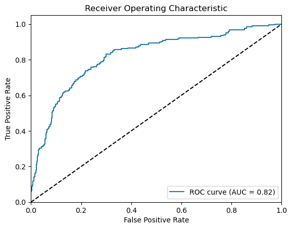

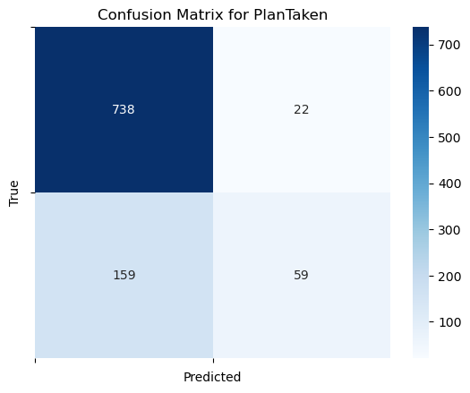

```python
def build_logistic_regression_model(X_train, X_test, y_train, y_test):
    lr_model = LogisticRegression()
    lr_model.fit(X_train, y_train)

    y_pred = lr_model.predict(X_test)
    y_prob = lr_model.predict_proba(X_test)[:, 1]

    show_auc_under_roc(y_test, y_pred, y_prob)
    show_confusion_matrix(y_test, y_pred)


build_logistic_regression_model(X_train, X_test, y_train, y_test)
```

## Round 2 - Logistic Regression with Regularization & SMOTE sampling

```
Accuracy:  0.7525562372188139
Precision: 0.8117865062015687
Recall: 0.7525562372188139
```

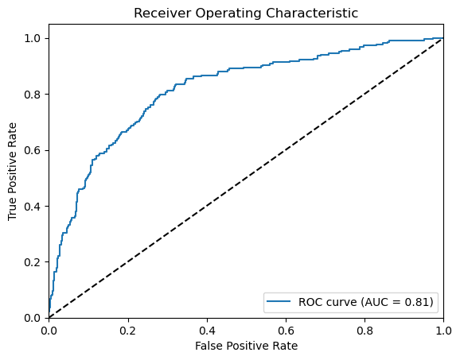

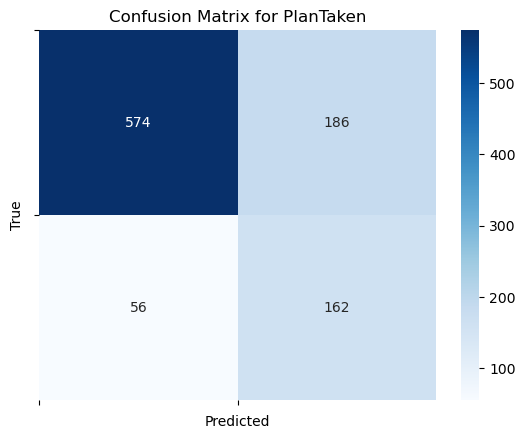

```python
def build_logistic_regression_model_with_regularization(X_train, X_test, y_train, y_test):
    smote = SMOTE(random_state=42)
    X_train_resampled, y_train_resampled = smote.fit_resample(X_train, y_train)

    lr_model = LogisticRegression(penalty="l2", C=12)
    lr_model.fit(X_train_resampled, y_train_resampled)

    y_pred = lr_model.predict(X_test)
    y_prob = lr_model.predict_proba(X_test)[:, 1]

    show_auc_under_roc(y_test, y_pred, y_prob)
    show_confusion_matrix(y_test, y_pred)

build_logistic_regression_model_with_regularization(X_train, X_test, y_train, y_test)
```

## Round 3 - Logistic Regression with Regularization & hyperparameter tuning & solver & SMOTE sampling

```
Accuracy:  0.7525562372188139
Precision: 0.8117865062015687
Recall: 0.7525562372188139
```

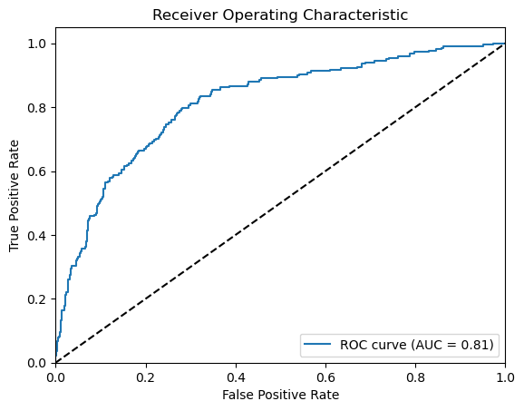

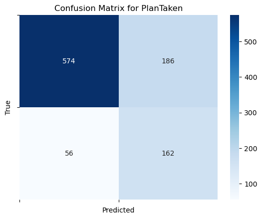

```python
def build_logistic_regression_model_with_regularization_and_tuning(X_train, X_test, y_train, y_test):
    smote = SMOTE(random_state=42)
    X_train_resampled, y_train_resampled = smote.fit_resample(X_train, y_train)

    lr_model = LogisticRegression(penalty="l2", C=13, solver="lbfgs")
    lr_model.fit(X_train_resampled, y_train_resampled)

    y_pred = lr_model.predict(X_test)
    y_prob = lr_model.predict_proba(X_test)[:, 1]

    show_auc_under_roc(y_test, y_pred, y_prob)
    show_confusion_matrix(y_test, y_pred)

build_logistic_regression_model_with_regularization_and_tuning(X_train, X_test, y_train, y_test)
```

# SVM

## Round 1 - SVM

```
Accuracy:  0.7770961145194274
Precision: 0.603878371201191
Recall: 0.7770961145194274
```

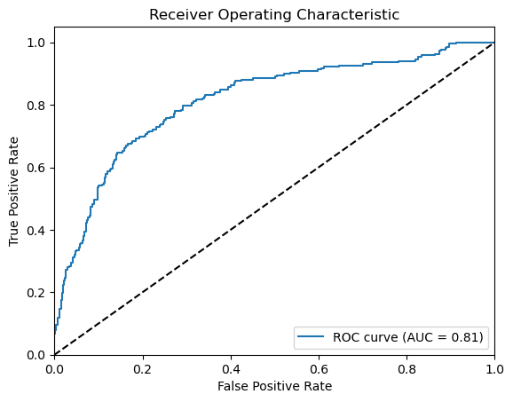

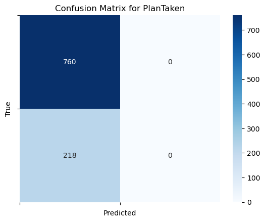

```python
def build_svm_model(X_train, X_test, y_train, y_test):
    svm_model = SVC(kernel='linear', probability=True)
    svm_model.fit(X_train, y_train)

    # Make predictions on the test set
    y_pred = svm_model.predict(X_test)
    cm = confusion_matrix(y_test, y_pred)


    y_prob = svm_model.predict_proba(X_test)[:, 1]

    show_auc_under_roc(y_test, y_pred, y_prob)
    show_confusion_matrix(y_test, y_pred)


build_svm_model(X_train, X_test, y_train, y_test)
```

**Conclusion - From the 0 values for false positive and true positive we see that the model is not learning using the "Linear" kernel**

## Round 2 - SVM with Regulariztion & `rbf` kernel

```
Accuracy:  0.9314928425357873
Precision: 0.9320768554095445
Recall: 0.9314928425357873
```

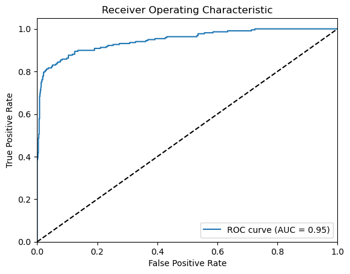

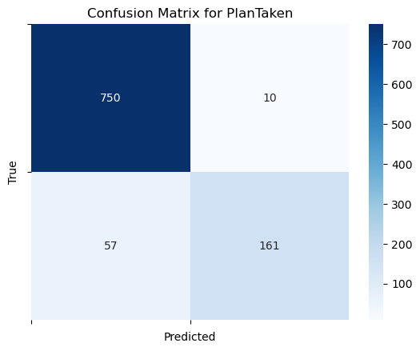

```python
def build_svm_model_with_regulariation_and_rbf(X_train, X_test, y_train, y_test):
    svm_model = SVC(kernel='rbf', C = 13.0, probability=True)
    svm_model.fit(X_train, y_train)

    # Make predictions on the test set
    y_pred = svm_model.predict(X_test)
    y_prob = svm_model.predict_proba(X_test)[:, 1]

    show_auc_under_roc(y_test, y_pred, y_prob)
    show_confusion_matrix(y_test, y_pred)

build_svm_model_with_regulariation_and_rbf(X_train, X_test, y_train, y_test)
```

## Round 3 - SVM with `rbf` kernel & Regularization & smote sampling

```
Accuracy:  0.9233128834355828
Precision: 0.9219368292162193
Recall: 0.9233128834355828
```

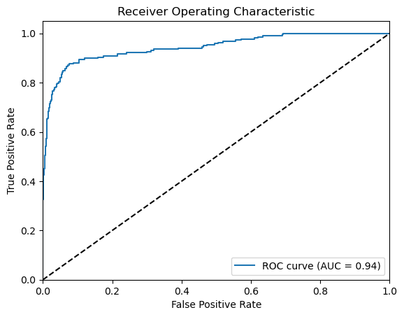

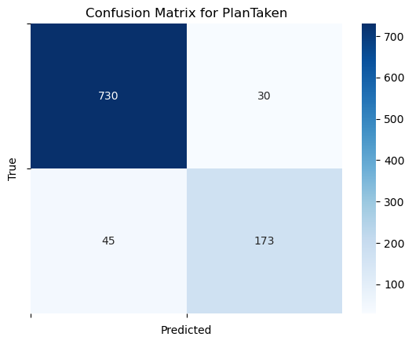

```python
def build_svm_model_with_regulariation_and_rbf_and_smote(X_train, X_test, y_train, y_test):
    smote = SMOTE(random_state=42)
    X_train_resampled, y_train_resampled = smote.fit_resample(X_train, y_train)

    svm_model = SVC(kernel='rbf', C=13.0, probability=True)
    svm_model.fit(X_train_resampled, y_train_resampled)

    # Make predictions on the test set
    y_pred = svm_model.predict(X_test)
    y_prob = svm_model.predict_proba(X_test)[:, 1]

    show_auc_under_roc(y_test, y_pred, y_prob)
    show_confusion_matrix(y_test, y_pred)

build_svm_model_with_regulariation_and_rbf_and_smote(X_train, X_test, y_train, y_test)
```

```python
X_train.shape
```

```
(3908, 29)
```

# Comparison between Logistic regression and Support vector machine.

- Time complexity

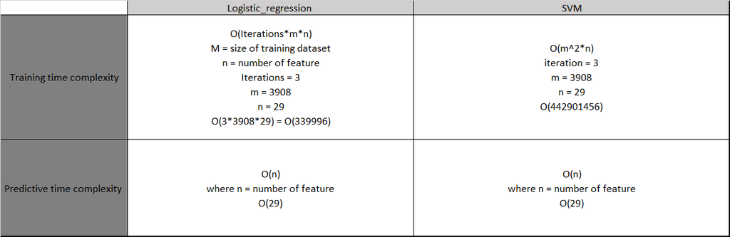

- If you compare Logistic regression and svm. Logistic regression takes less execution time than SVM.So, in case of execution time, logistic regression better than support vector machine .
- In case of multiple features classification support vector machine is better over logistic regression. SVM perform better in multiple dimensions (with respect to planes) over multiple features.
- Logistic regression accuracy = 0.75
- SVM accuracy = 0.92
- From above accuracy we can conclude two things SVM performed well with outliers and svm perform well with multiple features classification
- In case of Training time complexity(execution time) Logistic regression is better.
- In case of Predictive time complexity approx both perform same.